# Healthylife insurance charge prediction - Project 2

## Problem Statement

HealthyLife is a leading insurance company headquartered in New York City, serving customers nationwide with a range of insurance policies, including health, auto, and life insurance. Currently, the company relies on traditional methods to assess insurance charges based on customer details such as age, sex, and BMI. However, they face challenges in accurately predicting insurance charges due to limited insights into how different customer attributes impact premiums. This uncertainty leads to potential underpricing or overpricing of policies, affecting both profitability and customer satisfaction. To address these challenges, the company is looking to leverage advanced predictive modeling techniques to enhance its insurance charge estimation process and provide more accurate and personalized pricing to customers.

## Objective

As a Data Scientist hired by the insurance company, the objective is to develop an app and implement a predictive model for estimating insurance charges based on customer attributes. The primary challenges to solve include improving the accuracy of insurance charge predictions by incorporating various customer attributes, streamlining the underwriting process to enhance efficiency and customer experience, and maintaining regulatory compliance while optimizing pricing strategies also analyze and identify the driftness in model and data to understand the model behavior overtime

By achieving these objectives

- We aim to achieve more accurate and personalized insurance charge estimations
- Reducing the risks of underpricing and overpricing
- Improve customer satisfaction and loyalty through fair and competitive pricing
- Ensuring transparency and compliance with regulatory requirements in pricing strategies will further strengthen our competitive position in the market and enhance overall business performance

### Import the required libraries

```python
# Importing necessary libraries
import pandas as pd
import sklearn
import joblib
import matplotlib.pyplot as plt
import seaborn as sns

# Fetching dataset from sklearn's openml module
from sklearn.datasets import fetch_openml

# Importing preprocessing modules from sklearn
from sklearn.preprocessing import StandardScaler, OneHotEncoder, LabelEncoder
from sklearn.compose import make_column_transformer
from sklearn.impute import SimpleImputer
from sklearn.pipeline import Pipeline

# Importing make_pipeline function from pipeline module
from sklearn.pipeline import make_pipeline

# Importing train_test_split and RandomizedSearchCV from model_selection module
from sklearn.model_selection import train_test_split, RandomizedSearchCV

# Importing LogisticRegression model and evaluation metrics from linear_model and metrics modules
# from sklearn.linear_model import LogisticRegression
from sklearn.metrics import accuracy_score, classification_report
from sklearn.metrics import mean_squared_error, r2_score
from sklearn.linear_model import LinearRegression
```

```python
# Configure scikit-learn to display pipeline diagrams for visualizing the structure of machine learning pipelines
sklearn.set_config(display='diagram')
```

## Import the Data

```python
# Read the data
data_df = pd.read_csv("insurance.csv")
```

```python
data_df.sample(5)
```

|  | index | age | sex | bmi | children | smoker | region | charges |
| --- | --- | --- | --- | --- | --- | --- | --- | --- |
| 252 | 252 | 54 | male | 34.210 | 2 | yes | southeast | 44260.74990 |
| 720 | 720 | 51 | female | 40.660 | 0 | no | northeast | 9875.68040 |
| 1163 | 1163 | 18 | female | 28.215 | 0 | no | northeast | 2200.83085 |
| 1192 | 1192 | 58 | female | 32.395 | 1 | no | northeast | 13019.16105 |
| 977 | 977 | 26 | male | 29.150 | 1 | no | southeast | 2902.90650 |

```python
# Print the top 5 rows from the data
data_df.head()
```

|  | index | age | sex | bmi | children | smoker | region | charges |
| --- | --- | --- | --- | --- | --- | --- | --- | --- |
| 0 | 0 | 19 | female | 27.900 | 0 | yes | southwest | 16884.92400 |
| 1 | 1 | 18 | male | 33.770 | 1 | no | southeast | 1725.55230 |
| 2 | 2 | 28 | male | 33.000 | 3 | no | southeast | 4449.46200 |
| 3 | 3 | 33 | male | 22.705 | 0 | no | northwest | 21984.47061 |
| 4 | 4 | 32 | male | 28.880 | 0 | no | northwest | 3866.85520 |

# Data Description

- Index: Unique identifier for each record in the dataset
- age: Age os the customer
- bmi: Body Mass Index (BMI) of the customer
- children: Number of children/dependents covered by the insurance
- smoker: Indicates if the customer is a smoker (yes or no)
- region: Geographic region of the customer (e.g., northwest, southeast, southwest, northeast)
- charges: Estimated insurance charges for the customer based on the provided details

```python
data_df.info()
```

```
<class 'pandas.core.frame.DataFrame'>
RangeIndex: 1338 entries, 0 to 1337
Data columns (total 8 columns):
 #   Column    Non-Null Count  Dtype
---  ------    --------------  -----
 0   index     1338 non-null   int64
 1   age       1338 non-null   int64
 2   sex       1338 non-null   object
 3   bmi       1338 non-null   float64
 4   children  1338 non-null   int64
 5   smoker    1338 non-null   object
 6   region    1338 non-null   object
 7   charges   1338 non-null   float64
dtypes: float64(2), int64(3), object(3)
memory usage: 83.8+ KB
```

```python
# Get the column names in the dataset
data_df.columns
```

```
Index(['index', 'age', 'sex', 'bmi', 'children', 'smoker', 'region',
       'charges'],
      dtype='object')
```

```python
target = 'charges'
numeric_features = ['age', 'bmi', 'children']
categorical_features = ['sex', 'smoker','region']
```

```python
# Get the shape of the data
data_df.shape
```

```
(1338, 8)
```

```python
# Check is there any missing values iin the dataset
data_df.isnull().sum()
```

```
index       0
age         0
sex         0
bmi         0
children    0
smoker      0
region      0
charges     0
dtype: int64
```

```python
# Store the numerical features in a new varable called numerical_features
numerical_features =data_df[['age', 'bmi', 'children']].columns
```

```python
numerical_features
```

```
Index(['age', 'bmi', 'children'], dtype='object')
```

```python
# Store the categorical features in a new varable called categorical_features
categorical_features = data_df.select_dtypes(include=['object']).columns
```

```python
categorical_features
```

```
Index(['sex', 'smoker', 'region'], dtype='object')
```

```python
# Get the count of the children
data_df['children'].value_counts()
```

```
children
0    574
1    324
2    240
3    157
4     25
5     18
Name: count, dtype: int64
```

```python
# split data in to numerical and categorical
numerical_cols = data_df.select_dtypes(include=["int64", "float64"]).columns
categorical_cols = data_df.select_dtypes(include=["object"]).columns

# Create separate dataframes for numerical and categorical data
numerical_data = data_df[numerical_cols]
categorical_data = data_df[categorical_cols]
```

```python
numerical_data
```

|  | index | age | bmi | children | charges |
| --- | --- | --- | --- | --- | --- |
| 0 | 0 | 19 | 27.900 | 0 | 16884.92400 |
| 1 | 1 | 18 | 33.770 | 1 | 1725.55230 |
| 2 | 2 | 28 | 33.000 | 3 | 4449.46200 |
| 3 | 3 | 33 | 22.705 | 0 | 21984.47061 |
| 4 | 4 | 32 | 28.880 | 0 | 3866.85520 |
| ... | ... | ... | ... | ... | ... |
| 1333 | 1333 | 50 | 30.970 | 3 | 10600.54830 |
| 1334 | 1334 | 18 | 31.920 | 0 | 2205.98080 |
| 1335 | 1335 | 18 | 36.850 | 0 | 1629.83350 |
| 1336 | 1336 | 21 | 25.800 | 0 | 2007.94500 |
| 1337 | 1337 | 61 | 29.070 | 0 | 29141.36030 |

1338 rows × 5 columns

#### Distributions

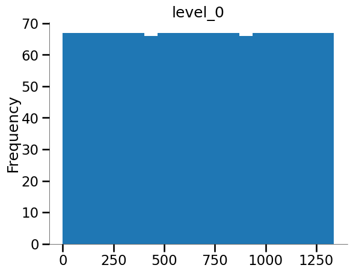

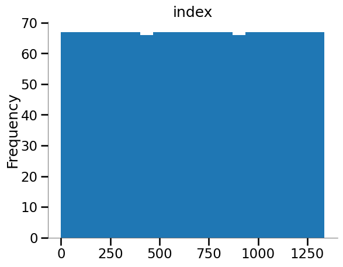

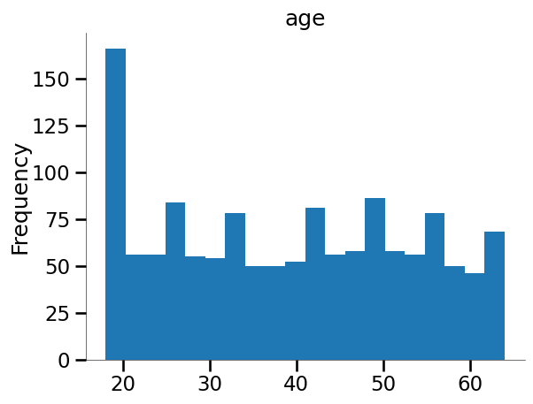

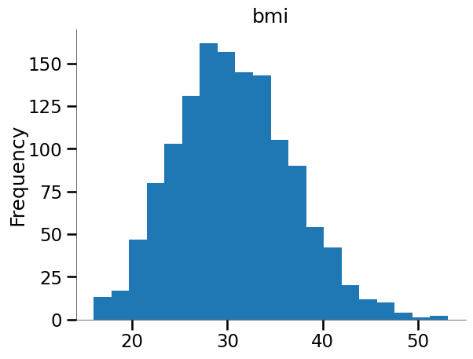

#### 2-d distributions

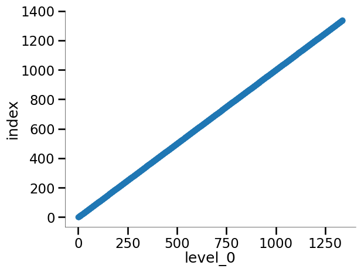

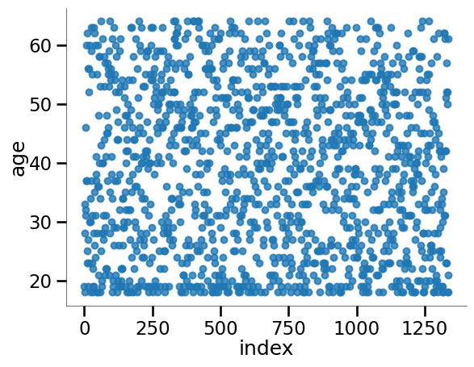

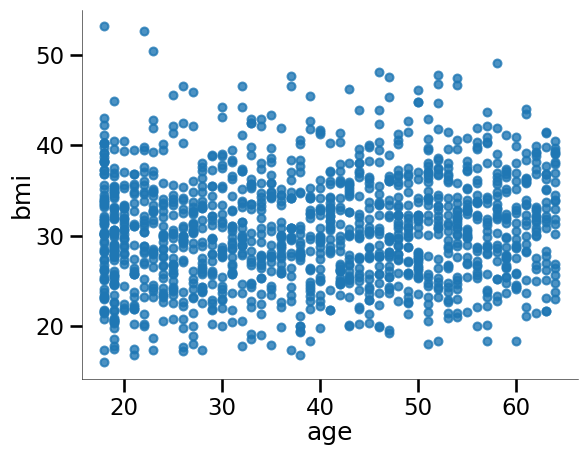

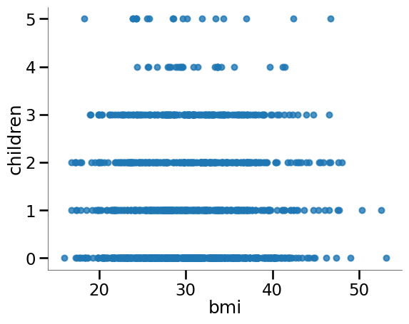

#### Time series

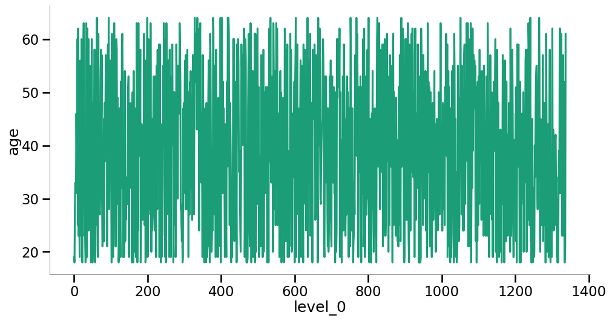

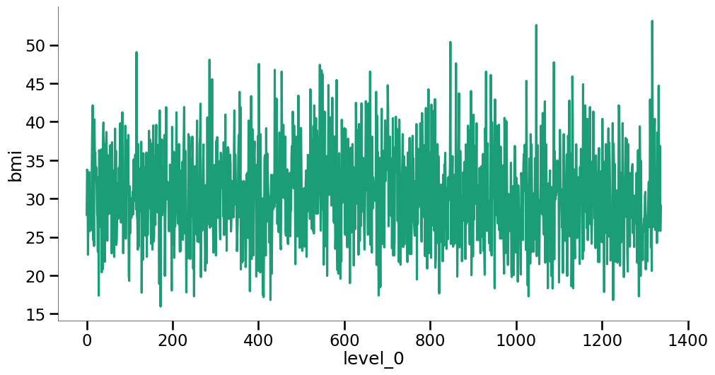

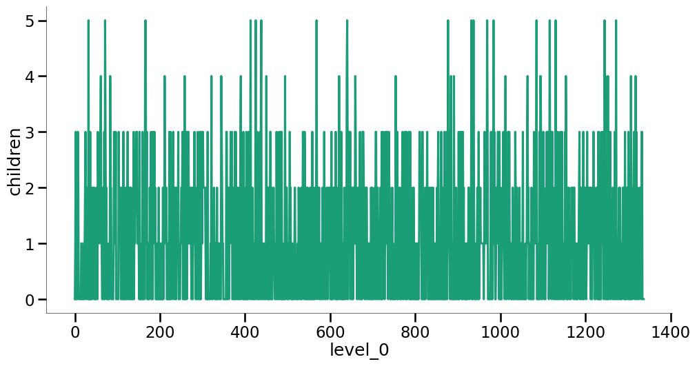

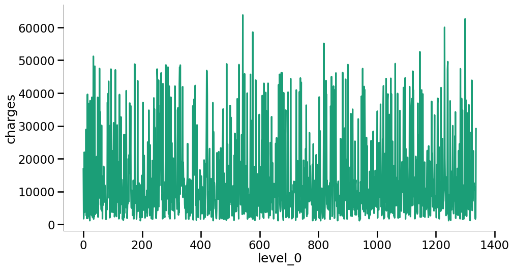

#### Values

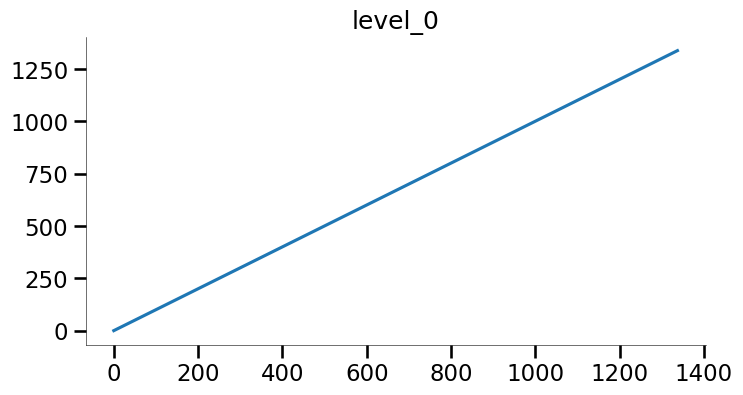

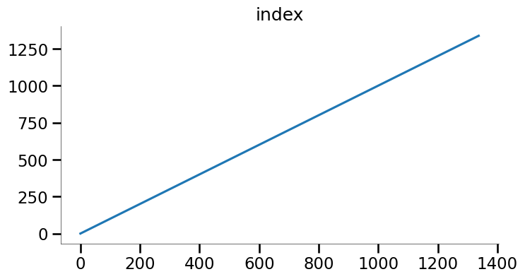

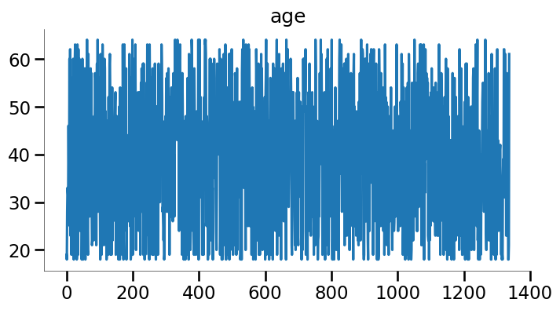

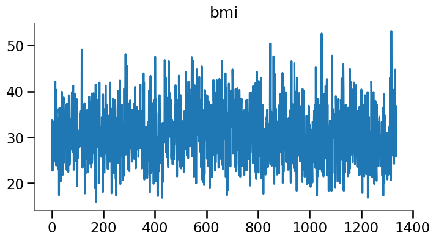

```python
categorical_data
```

|  | sex | smoker | region |
| --- | --- | --- | --- |
| 0 | female | yes | southwest |
| 1 | male | no | southeast |
| 2 | male | no | southeast |
| 3 | male | no | northwest |
| 4 | male | no | northwest |
| ... | ... | ... | ... |
| 1333 | male | no | northwest |
| 1334 | female | no | northeast |
| 1335 | female | no | southeast |
| 1336 | female | no | southwest |
| 1337 | female | yes | northwest |

1338 rows × 3 columns

#### Distributions

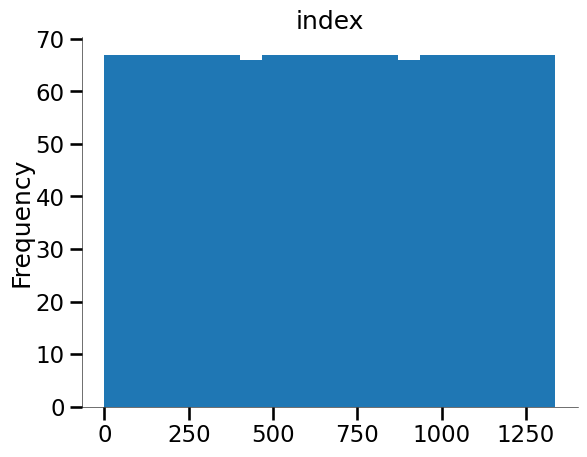

#### Categorical distributions

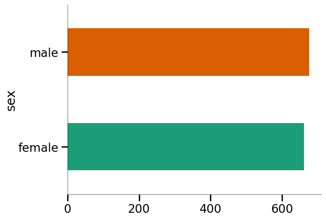

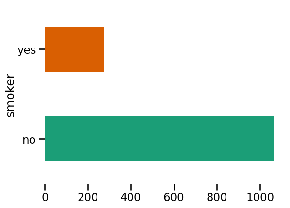

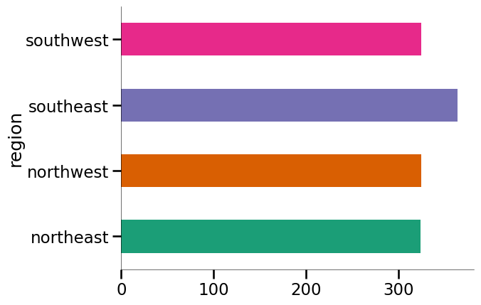

#### Time series

[figure not shown]

[figure not shown]

[figure not shown]

#### Values

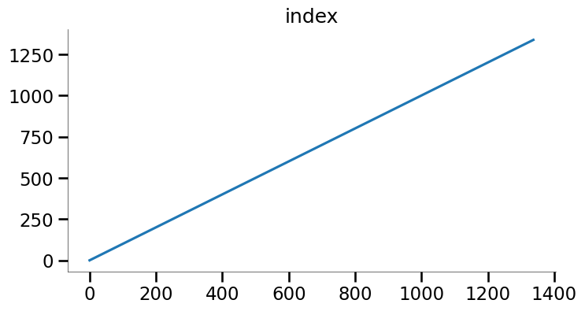

#### 2-d categorical distributions

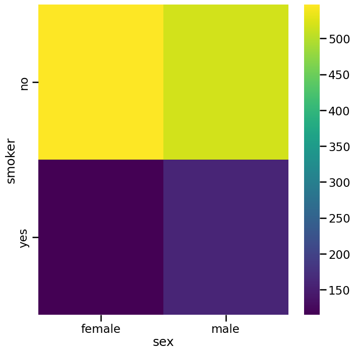

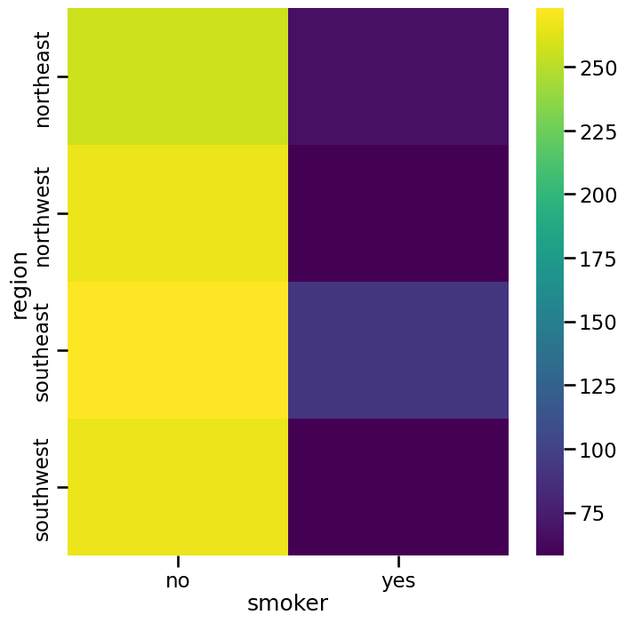

#### Faceted distributions

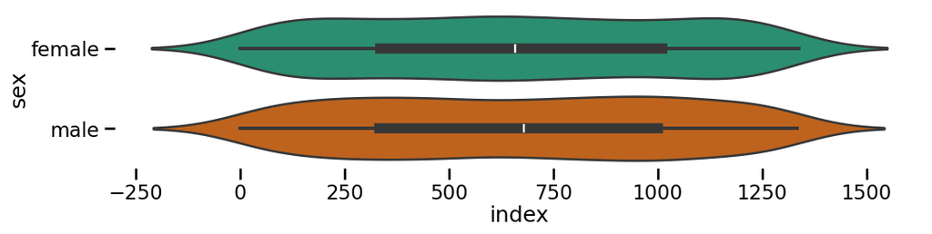

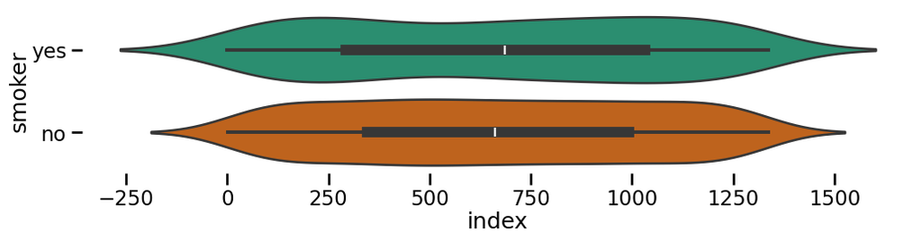

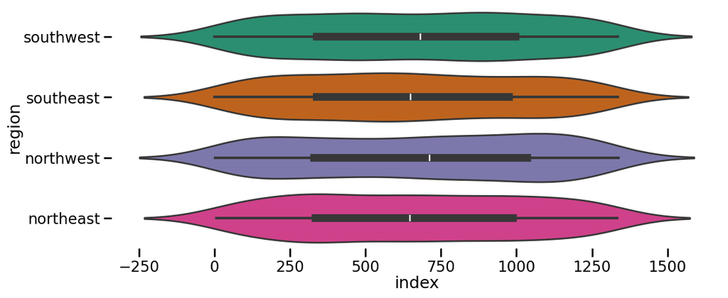

```python
from matplotlib import pyplot as plt
import seaborn as sns
import pandas as pd
plt.subplots(figsize=(8, 8))
df_2dhist = pd.DataFrame({
    x_label: grp['smoker'].value_counts()
    for x_label, grp in _df_24.groupby('sex')
})
sns.heatmap(df_2dhist, cmap='viridis')
plt.xlabel('sex')
_ = plt.ylabel('smoker')
```

[figure not shown]

# Display the statistical summary of the numerical, categorical and target data

```python
# Display statistical summary of numerical data
numerical_summary = numerical_data.describe()
print("Statistical summary of numerical data:")
print(numerical_summary)
```

```
Statistical summary of numerical data:
             index          age          bmi     children       charges
count  1338.000000  1338.000000  1338.000000  1338.000000   1338.000000
mean    668.500000    39.207025    30.663397     1.094918  13270.422265
std     386.391641    14.049960     6.098187     1.205493  12110.011237
min       0.000000    18.000000    15.960000     0.000000   1121.873900
25%     334.250000    27.000000    26.296250     0.000000   4740.287150
50%     668.500000    39.000000    30.400000     1.000000   9382.033000
75%    1002.750000    51.000000    34.693750     2.000000  16639.912515
max    1337.000000    64.000000    53.130000     5.000000  63770.428010
```

```python
# Display statistical summary of categorical data
categorical_summary = categorical_data.describe(include="all")
print("\nStatistical summary of categorical data:")
print(categorical_summary)
```

```
Statistical summary of categorical data:
         sex smoker     region
count   1338   1338       1338
unique     2      2          4
top     male     no  southeast
freq     676   1064        364
```

```python
# Display statistical summary of target data
target_data = data_df["charges"]
target_summary = target_data.describe()
print("\nStatistical summary of target data:")
print(target_summary)
```

```
Statistical summary of target data:
count     1338.000000
mean     13270.422265
std      12110.011237
min       1121.873900
25%       4740.287150
50%       9382.033000
75%      16639.912515
max      63770.428010
Name: charges, dtype: float64
```

#### Write your insights and findings from the statistical summary

Based on the statistical summary of the data, here are some insights and findings:

#### Categorical Data:

- -- Sex: The dataset includes both male and female individuals, with no missing values.
- -- Smoker: The dataset contains information about smoking habits, with 'yes' indicating smokers and 'no' indicating non-smokers.
- -- Region: The dataset includes individuals from different regions, namely 'southwest', 'southeast', 'northwest', and 'northeast'.

#### Target Data:

- -- Charges: The charges variable represents the insurance charges for individuals. The statistical summary provides information about the minimum, maximum, mean, and quartile values, giving an overview of the distribution of insurance charges.

```python
# Check for missing values
missing_values = data_df.isnull().sum()

print("Missing values in the dataset:")
print(missing_values)
```

```
Missing values in the dataset:
index       0
age         0
sex         0
bmi         0
children    0
smoker      0
region      0
charges     0
dtype: int64
```

```python
# Check for duplicated rows
duplicated_rows = data_df[data_df.duplicated()]

# Print the duplicated rows
print("Duplicated rows:")
print(duplicated_rows)
```

```
Duplicated rows:
Empty DataFrame
Columns: [index, age, sex, bmi, children, smoker, region, charges]
Index: []
```

```python
data_df.duplicated().sum()
```

```
0
```

```python
# display the info of the dataset
data_df.info()
```

```
<class 'pandas.core.frame.DataFrame'>
RangeIndex: 1338 entries, 0 to 1337
Data columns (total 8 columns):
 #   Column    Non-Null Count  Dtype
---  ------    --------------  -----
 0   index     1338 non-null   int64
 1   age       1338 non-null   int64
 2   sex       1338 non-null   object
 3   bmi       1338 non-null   float64
 4   children  1338 non-null   int64
 5   smoker    1338 non-null   object
 6   region    1338 non-null   object
 7   charges   1338 non-null   float64
dtypes: float64(2), int64(3), object(3)
memory usage: 83.8+ KB
```

```python
# drop the columns which was not required for modelling
# List of columns to drop
columns_to_drop = ['index']

# Drop the columns
data_df = data_df.drop(columns=columns_to_drop)

# Display the modified DataFrame
print(data_df)
```

```
      age     sex     bmi  children smoker     region      charges
0      19  female  27.900         0    yes  southwest  16884.92400
1      18    male  33.770         1     no  southeast   1725.55230
2      28    male  33.000         3     no  southeast   4449.46200
3      33    male  22.705         0     no  northwest  21984.47061
4      32    male  28.880         0     no  northwest   3866.85520
...   ...     ...     ...       ...    ...        ...          ...
1333   50    male  30.970         3     no  northwest  10600.54830
1334   18  female  31.920         0     no  northeast   2205.98080
1335   18  female  36.850         0     no  southeast   1629.83350
1336   21  female  25.800         0     no  southwest   2007.94500
1337   61  female  29.070         0    yes  northwest  29141.36030

[1338 rows x 7 columns]
```

## Exploratory data analysis

#### Charges amount distribution per sex

```python
# Display a histogram to visualize the distribution of charges based on sex in the dataset
# Filter the data by sex
plt.figure(figsize=(9,6))
plt.xlabel('Charges')
plt.ylabel('Frequency')
plt.title('Distribution of Charges by Sex')

sns.histplot(data_df, x='charges',hue="sex", kde=True, alpha=0.6, linewidth=1)
```

[figure not shown]

It appears that the charges for males and females are the same; however, there are more males then females with chages exceeding $3200

#### Distribution of Age

```python
# Create a histogram to display the age distribution in the dataset
plt.figure(figsize=(9,6))
# Set plot labels and title
plt.xlabel('Age')
plt.ylabel('Frequency')
plt.title('Age Distribution')
sns.histplot(data_df, x='age', kde=True, alpha=0.6, bins=20, linewidth=2)
```

[figure not shown]

#### Charges amount distribution per smoker

```python
# Show a histogram to visualize the distribution of charges amounts based on smoking status in the dataset
plt.figure(figsize=(9,6))
# Set plot labels and title
plt.xlabel('Charges')
plt.ylabel('Frequency')
plt.title('Distribution of Charges by Smoking Status')


sns.histplot(data_df, x='charges', hue="smoker", kde=True, alpha=0.6, linewidth=1)
```

[figure not shown]

#### Average BMI per age

```python
# Display a line plot showing the average BMI per age using markers to highlight the data points
plt.figure(figsize=(14,6))
sns.lineplot(data_df, x='age', y='bmi',  marker='o', linewidth=4, markersize=10, markerfacecolor="white", markeredgewidth=2)

# Set plot labels and title
plt.xlabel('Age')
plt.ylabel('Average BMI')
plt.title('Average BMI per Age')
plt.style.use("ggplot")
# Show the plot
plt.show()
```

[figure not shown]

As we can see with time - the average BMI score starts getting higher to unhealthier ranges.

#### Age vs charges

```python
# Create a scatter plot to show the relationship between age and charges in the dataset.
plt.figure(figsize=(14,6))
sns.scatterplot(data_df, x='age', y='charges', s=30)

# Set plot labels and title
plt.xlabel('Age')
plt.ylabel('Charges')
plt.title('Relationship between Age and Charges')
plt.style.use("ggplot")
# Show the plot
plt.show()
```

[figure not shown]

## Model Estimation

```python
categorical_features
```

```
Index(['sex', 'smoker', 'region'], dtype='object')
```

```python
numerical_features
```

```
Index(['age', 'bmi', 'children'], dtype='object')
```

```python
target = 'charges'
numeric_features = ['age', 'bmi', 'children']
categorical_features = ['sex', 'smoker','region']
```

```python
X = data_df[numeric_features + categorical_features]
y = data_df[target]
```

```python
# Split the data into training and testing sets
# Xtrain, Xtest, ytrain, ytest = train_test_split(X, y, test_size=0.2, random_state=42)
# Split the independenet and dependent features in to x and y variables with a test size 0.2% and random at 42
Xtrain, Xtest, ytrain, ytest = train_test_split(
    X, y,
    test_size=0.2,
    random_state=42
)
```

'scaler': Standardizes the numerical features using StandardScaler.

```python
# Creating a pipeline for categorical feature processing, including imputation of missing values with the most frequent value and one-hot encoding with handling of unknown categories.
categorical_pipeline = Pipeline([
    ('imputer', SimpleImputer(strategy='most_frequent')),
    ('onehot', OneHotEncoder(handle_unknown='ignore'))
])
```

This code constructs a pipeline named categorical_pipeline for processing categorical features, involving imputation of missing values using the most frequent value and one-hot encoding with handling of unknown categories.

```python
# Creating a column transformer named preprocessor to apply specific pipelines to numerical and categorical features separately.
preprocessor = make_column_transformer(
    (StandardScaler(), numeric_features),
    (OneHotEncoder(handle_unknown='ignore'), categorical_features)
)
```

```python
# Creating a Linear regression model with parallel processing enabled (-1 indicates using all available cores) for improved training efficiency.
model_linear_regression = LinearRegression(n_jobs=-1)
```

```python
# Creating a pipeline combining preprocessing steps (imputation and encoding) with logistic regression modeling.
model_pipeline = make_pipeline(
    preprocessor,  # Applying preprocessing steps
    model_linear_regression  # Training logistic regression model
)
```

```python
# Fit the model on training data
model_pipeline.fit(Xtrain, ytrain)
```

```
Pipeline(steps=[('columntransformer',
                 ColumnTransformer(transformers=[('standardscaler',
                                                  StandardScaler(),
                                                  ['age', 'bmi', 'children']),
                                                 ('onehotencoder',
                                                  OneHotEncoder(handle_unknown='ignore'),
                                                  ['sex', 'smoker',
                                                   'region'])])),
                ('linearregression', LinearRegression(n_jobs=-1))])
```

## Model Evaluation

```python
# Make predictions on the testing data
model_pipeline.predict(Xtest)
```

[output not shown]

[output cut: 12 more lines]

```
       13261.42480211,  1120.17810533, 10386.66427709, 10567.29006474,
       16944.25995713, 26846.54662457,  6939.11178393,  5193.04710054,
        5846.00017265, 13229.60536846, 11098.33930228,  8362.28134289,
        5135.53940151, 12308.34064139, 13861.17886997, 35773.70926219,
        4157.01930317, 28917.86562624,  -914.37342357,  2873.71150671,
       11046.2540774 , 15683.06950225,  5210.67532324,  6888.38518351,
        3854.31140958, 31312.64705453,  7241.43226665, 12405.99508651,
        5619.17039188,  9528.22557021, 36314.009043  ,  4429.40596906,
        9667.91523953, 31161.15738995,  5747.13292318,  4603.37294255,
        1048.35533791,  4832.6604097 ,  4574.9041044 ,  6507.30666036,
       18659.12407756, -1545.57184934,  2376.4352498 , 10694.62157146,
        3151.28919904, 10209.96361187,  3733.89128353,  5125.08103172,
       12400.90700504,  6218.65296628,  8231.63765089,  7590.50155269,
        8924.15352268, 10482.90359975, 27808.04576398, 39061.50093248,
       11761.4991981 ,  7687.56363151, 40920.29151165, 12318.58665305])
```

```python
# Evaluate the model using mean squared error
print(f"RMSE: {mean_squared_error(ytest, model_pipeline.predict(Xtest), squared=False)}")
```

```
RMSE: 5796.284659276274
```

```python
# Evaluate the model using R-squared score
print(f"R-squared: {r2_score(ytest, model_pipeline.predict(Xtest))}")
```

```
R-squared: 0.7835929767120722
```

## Serialization

```python
# Display information about the scikit-learn package
print("Scikit-learn version:", sklearn.__version__)

# Display scikit-learn package information
print(sklearn)
```

```
Scikit-learn version: 1.2.2
<module 'sklearn' from '/usr/local/lib/python3.10/dist-packages/sklearn/__init__.py'>
```

```python
# This command displays information about the installed version of the scikit-learn library.
!pip show scikit-learn
```

```
Name: scikit-learn
Version: 1.2.2
Summary: A set of python modules for machine learning and data mining
Home-page: http://scikit-learn.org
Author:
Author-email:
License: new BSD
Location: /usr/local/lib/python3.10/dist-packages
Requires: joblib, numpy, scipy, threadpoolctl
Required-by: bigframes, fastai, imbalanced-learn, librosa, mlxtend, qudida, sklearn-pandas, yellowbrick
```

```python
# Generate a requirements.txt file for the project's dependencies
%%writefile requirements.txt
scikit-learn==1.2.2
```

```
Overwriting requirements.txt
```

```python
%%writefile train.py
import pandas as pd
import joblib

from sklearn.datasets import fetch_openml

from sklearn.preprocessing import StandardScaler, OneHotEncoder
from sklearn.compose import make_column_transformer

from sklearn.pipeline import make_pipeline

from sklearn.model_selection import train_test_split

from sklearn.linear_model import LinearRegression
from sklearn.metrics import mean_squared_error, r2_score

# Read the data
data_df = pd.read_csv("insurance.csv")

target = 'charges'
numeric_features = ['age', 'bmi', 'children']
categorical_features = ['sex', 'smoker','region']

print("Creating data subsets")

X = data_df[numeric_features + categorical_features]
y = data_df[target]

Xtrain, Xtest, ytrain, ytest = train_test_split(
    X, y,
    test_size=0.2,
    random_state=42
)

preprocessor = make_column_transformer(
    (StandardScaler(), numeric_features),
    (OneHotEncoder(handle_unknown='ignore'), categorical_features)
)

model_linear_regression = LinearRegression(n_jobs=-1)

print("Estimating Model Pipeline")

model_pipeline = make_pipeline(
    preprocessor,
    model_linear_regression
)

model_pipeline.fit(Xtrain, ytrain)

print("Logging Metrics")
print(f"R-squared: {r2_score(ytest, model_pipeline.predict(Xtest))}")

print("Serializing Model")

saved_model_path = "model.joblib"

joblib.dump(model_pipeline, saved_model_path)
```

```
Overwriting train.py
```

```python
# Execute the training script
# Run the script
!python train.py
```

```
Creating data subsets
Estimating Model Pipeline
Logging Metrics
R-squared: 0.7835929767120722
Serializing Model
```

## Test Predictions

```python
# write you are code here
# Load the saved model
saved_model = joblib.load("model.joblib")
```

```python
# Get the architecture of saved model
saved_model
```

```
Pipeline(steps=[('columntransformer',
                 ColumnTransformer(transformers=[('standardscaler',
                                                  StandardScaler(),
                                                  ['age', 'bmi', 'children']),
                                                 ('onehotencoder',
                                                  OneHotEncoder(handle_unknown='ignore'),
                                                  ['sex', 'smoker',
                                                   'region'])])),
                ('linearregression', LinearRegression(n_jobs=-1))])
```

```python
saved_model.predict(Xtest)
```

[output not shown]

[output cut: 12 more lines]

```
       13261.42480211,  1120.17810533, 10386.66427709, 10567.29006474,
       16944.25995713, 26846.54662457,  6939.11178393,  5193.04710054,
        5846.00017265, 13229.60536846, 11098.33930228,  8362.28134289,
        5135.53940151, 12308.34064139, 13861.17886997, 35773.70926219,
        4157.01930317, 28917.86562624,  -914.37342357,  2873.71150671,
       11046.2540774 , 15683.06950225,  5210.67532324,  6888.38518351,
        3854.31140958, 31312.64705453,  7241.43226665, 12405.99508651,
        5619.17039188,  9528.22557021, 36314.009043  ,  4429.40596906,
        9667.91523953, 31161.15738995,  5747.13292318,  4603.37294255,
        1048.35533791,  4832.6604097 ,  4574.9041044 ,  6507.30666036,
       18659.12407756, -1545.57184934,  2376.4352498 , 10694.62157146,
        3151.28919904, 10209.96361187,  3733.89128353,  5125.08103172,
       12400.90700504,  6218.65296628,  8231.63765089,  7590.50155269,
        8924.15352268, 10482.90359975, 27808.04576398, 39061.50093248,
       11761.4991981 ,  7687.56363151, 40920.29151165, 12318.58665305])
```

# Gradio Interface

```python
import pandas as pd

# Read the CSV file
df = pd.read_csv("insurance.csv")

# Get distinct values for each column
distinct_values = {}
for column in df.columns:
    distinct_values[column] = df[column].unique()

# Print distinct values for each column
for column, values in distinct_values.items():
    print(f"Distinct values for column '{column}':")
    print(values)
    print()
```

[output not shown]

[output cut: 23 more lines]

```
 33.3   39.14  21.945 24.97  23.94  34.485 21.8   23.3   36.96  21.28
 29.4   27.3   37.9   37.715 23.76  25.52  27.61  27.06  39.4   34.9
 22.    30.36  27.8   53.13  39.71  32.87  44.7   30.97 ]

Distinct values for column 'children':
[0 1 3 2 5 4]

Distinct values for column 'smoker':
['yes' 'no']

Distinct values for column 'region':
['southwest' 'southeast' 'northwest' 'northeast']

Distinct values for column 'charges':
[16884.924   1725.5523  4449.462  ...  1629.8335  2007.945  29141.3603]
```

```python
%%writefile app.py
# Import the libraries
import os
import uuid
import joblib
import json

import gradio as gr
import pandas as pd

from huggingface_hub import CommitScheduler
from pathlib import Path


# Run the training script placed in the same directory as app.py
# The training script will train and persist a linear regression
# model with the filename 'model.joblib'

os.system("pyhton train.py")

# Load the freshly trained model from disk
insurance_charges_predictor = joblib.load('model.joblib')

# Prepare the logging functionality
log_file = Path("logs/") / f"data_{uuid.uuid4()}.json"
log_folder = log_file.parent

scheduler = CommitScheduler(
    repo_id="insurance-charge-mlops-logs",  # provide a name "insurance-charge-mlops-logs" for the repo_id
    repo_type="dataset",
    folder_path=log_folder,
    path_in_repo="data",
    every=2
)

# Define the predict function which will take features, convert to dataframe and make predictions using the saved model
# the functions runs when 'Submit' is clicked or when a API request is made


def predict_insurance_charge(age, bmi, children, sex, smoker, region):
    sample = {
        'age': age,
        'bmi': bmi,
        'children': children,
        'sex': sex,
        'smoker': smoker,
        'region': region
    }
    data_point = pd.DataFrame([sample])
    prediction = insurance_charges_predictor.predict(data_point).tolist()


    # While the prediction is made, log both the inputs and outputs to a  log file
    # While writing to the log file, ensure that the commit scheduler is locked to avoid parallel
    # access

    with scheduler.lock:
        with log_file.open("a") as f:
            f.write(json.dumps(
                {
                    'age': age,
                    'bmi': bmi,
                    'children': children,
                    'sex': sex,
                    'smoker': smoker,
                    'region': region,
                    'prediction': prediction[0]
                }
            ))
            f.write("\n")

    return prediction[0]



# Set up UI components for input and output


age_input = gr.Number(label="Age")
bmi_input = gr.Number(label="BMI")
children_input = gr.Number(label="Children")
sex_input = gr.Dropdown(["female","male"],label="Sex")
smoker_input = gr.Dropdown(["yes", "no"],label="Smoker")
region_input = gr.Dropdown(["southwest", "southeast", "northwest", "northeast"],label="Region")

model_output = gr.Label(label="HealthyLife Insurance Charge Prediction - Predict the cost for your Medical Insurance!")

# Create the gradio interface, make title "HealthyLife Insurance Charge Prediction"
demo = gr.Interface(
    fn=predict_insurance_charge,
    #age, bmi, children, sex, smoker, region
    inputs=[age_input, bmi_input, children_input,
            sex_input, smoker_input, region_input],
    outputs=model_output,
    title="HealthyLife Insurance Charge Prediction",
    description="This API allows you to predict the HealthyLife Insurance Charge",
    allow_flagging="auto",
    examples=[[33,33,44,5,'male','no','southeast'],
              [50,25,175,0,'male',' no','northeast'],
              [52,38,380,2,'female',' no','northeast']],
    concurrency_limit=16
)

# Launch with a load balancer
demo.queue()
demo.launch(share=False)
```

```
Overwriting app.py
```

```python
%%writefile app.py
import os
import uuid
import joblib
import json

import gradio as gr
import pandas as pd

from huggingface_hub import CommitScheduler
from pathlib import Path

# Run the training script placed in the same directory as app.py
# The training script will train and persist a logistic regression
# model with the filename 'model.joblib'

os.system("python train.py")

# Load the freshly trained model from disk

insurance_charge_predictor = joblib.load('model.joblib')

# Prepare the logging functionality

log_file = Path("logs/") / f"data_{uuid.uuid4()}.json"
log_folder = log_file.parent

scheduler = CommitScheduler(
    repo_id="insurance-charge-mlops-logs",
    repo_type="dataset",
    folder_path=log_folder,
    path_in_repo="data",
    every=2
)

# Define the predict function that runs when 'Submit' is clicked or when a API request is made
def predict_insurance_charge(age, bmi, children,sex, smoker, region):
    sample = {
        'age': age,
        'bmi': bmi,
        'children': children,
        'sex': sex,
        'smoker': smoker,
        'region': region
    }

    data_point = pd.DataFrame([sample])
    prediction = insurance_charge_predictor.predict(data_point).tolist()

    # While the prediction is made, log both the inputs and outputs to a local log file
    # While writing to the log file, ensure that the commit scheduler is locked to avoid parallel
    # access

    with scheduler.lock:
        with log_file.open("a") as f:
            f.write(json.dumps(
                {
                    'age': age,
                    'bmi': bmi,
                    'children': children,
                    'sex': sex,
                    'smoker': smoker,
                    'region': region,
                    'prediction': prediction[0]
                }
            ))
            f.write("\n")

    return round(prediction[0],2)

# Set up UI components for input and output

age_input = gr.Number(label='Age')
bmi_input = gr.Number(label='BMI')
children_input = gr.Number(label='Children')
sex_input = gr.Dropdown(['female','male'],label='Sex')
smoker_input = gr.Dropdown(['yes','no'],label='Smoker')
region_input = gr.Dropdown(
    ['southeast', 'southwest', 'northwest', 'northeast'],
    label='Region'
)

model_output = gr.Label(label="HealthyLife Insurance Charge Prediction - Predict the cost for your Medical Insurance!")

# Create the interface
demo = gr.Interface(
    fn=predict_insurance_charge,
    inputs=[age_input, bmi_input, children_input,sex_input, smoker_input, region_input],
    outputs=model_output,
    title="HealthyLife Insurance Charge Prediction",
    description="This API allows you to predict the estimating insurance charges based on customer attributes",
    examples=[[33,33.44,5,'male','no','southeast'],
              [58,25.175,0,'male','no','northeast'],
              [52,38.380,2,'female','no','northeast']],
    concurrency_limit=16
)

# Launch with a load balancer
demo.queue()
demo.launch(share=False)
```

```
Overwriting app.py
```